# RCT HF vs. iTBS

Meths & Stats

Author

Josef Mana

# Methods

## Data analysis

All baseline demographic and clinical variables were described as means ± standard deviations if continuous (age, years of education and device energy) and as group-specific frequencies if categorical (sex, study completion, termination phase and medication types). A series of independent samples t tests with Welch’s approximation to the degrees of freedom was used to test the hypothesis of zero between-group difference in means of continuous variables. A series of Pearson’s $\chi^2$ tests was used to test the hypothesis that the randomization group and each categorical variable are stochastically independent of each other. The primary analysis was a per-protocol analysis that included participants who finished the study protocol in full including complete data in all outcome measures. Per-protocol average treatment effect (ATE) and its difference between randomization groups was estimated using a series of mixed ANOVAs with each outcome measure regressed on the randomization group as a between-subject factor, timepoint as a within-subject factor and their interaction. Decision about rejection of a hypothesis of zero mean difference with respect to each of these terms was based on an F test with p-value adjusted by Benjamini-Hochberg procedure (Benjamini & Yekutieli, 2001) for 5% false discovery rate (FDR) across all outcomes of interest. Thus effects associated with terms with adjusted p-value (i.e., the q-value) less than .05 were considered statistically significantly different from zero. This analysis was followed by inspection of pairwise comparisons between timepoints averaged over randomization groups (the main effect of timepoint) and conditional on randomization group (the simple main effect timepoint) as well as between randomization groups conditional on timepoint (the simple main effect of randomization group). Furthermore, response and remission rates were calculated for timepoints T1 and T2 and the hypothesis that the randomization group and response/remission rate are stochastically independent were tested via Pearson’s $\chi^2$ tests separately for each timepoint. To describe individual response to treatment more directly, percentage changes[^1] in T1 and T2 compared to T0 across depression and anxiety outcomes was calculated for each participant included in the per-protocol analysis and described by their means and standard deviations. Finally, a modified intention-to-treat analysis was conducted on the full sample using a set of linear mixed effects models whereby each outcome measure was regressed on randomization group, timepoint and their interaction on group level (the “fixed effects”), and subject-specific intercepts on subject level (the “random effects”). Results of these models were then analysed using a set of ANOVAs and pairwise comparisons analogous to the per-protocol analysis. All analyses were conducted in R version 4.3.3 using package “rstatix” for mixed ANOVAs and “lmer4” with “lmerTest” for mixed effect models (Bates et al., 2015; Kassambara, 2023; Kuznetsova et al., 2017; R Core Team, 2024). Computer code to produce presented results is available at https://github.com/josefmana/deprtms.git.

# Results

## Participant demographics

One hundred eight subjects were randomized (mean age = 47.23; range = 19-78; 66% females; n = 60 in iTBS group; n = 48 in the HF-rTMS group). Baseline demographics are presented in Table 1. We did not detect any statistically significant difference between randomization groups in demographic variables, clinical variables, completion rates or termination phase. The outcome variables are summarized in Table 2 for the sample used in the per-protocol analysis and Table 5 for the full sample. The data used for the per-protocol analysis are further summarised in Figure 1.

Table 1

Table 1 Subject demographics. Demographics for the two groups after randomization.

|  | HF-rTMS | iTBS | Stats |
| --- | --- | --- | --- |
| Sex |  |  |  |
| female | 36 (75.0%) | 35 (58.3%) | χ2(1) = 2.59, p = .108 |
| male | 12 (25.0%) | 25 (41.7%) |  |
| Age (years) |  |  |  |
|  | 46.69 ± 16.54 | 47.67 ± 15.32 | t(97.17) = -0.32, p = .753 |
| Education (years) |  |  |  |
|  | 14.40 ± 2.58 | 13.43 ± 3.17 | t(105.96) = 1.74, p = .085 |
| Medication |  |  |  |
| Antidepressants | 33 (68.8%) | 40 (66.7%) | χ2(1) = 0.00, p = .982 |
| Antipsychotics | 8 (16.7%) | 7 (11.7%) | χ2(1) = 0.22, p = .641 |
| Benzodiazepines | 21 (43.8%) | 21 (35.0%) | χ2(1) = 0.53, p = .466 |
| Mood stabilizers | 7 (14.6%) | 11 (18.3%) | χ2(1) = 0.07, p = .795 |
| Non-benzodiazepine anxiolitics/Hypnotics | 3 (6.2%) | 5 (8.3%) | χ2(1) = 0.00, p = .967 |
| Stimulants | 0 (0.0%) | 0 (0.0%) | χ2(1) = 1.33, p = .248 |
| Completed |  |  |  |
| 0 | 14 (29.2%) | 18 (30.0%) | χ2(1) = 0.00, p = 1.000 |
| 1 | 34 (70.8%) | 42 (70.0%) |  |
| Termination phase |  |  |  |
| none | 34 (70.8%) | 42 (70.0%) | χ2(2) = 1.66, p = .435 |
| T1 | 7 (14.6%) | 5 (8.3%) |  |
| T2 | 7 (14.6%) | 13 (21.7%) |  |
| Device energy (% of maximum capacity) |  |  |  |
|  | 50.90 ± 8.90 | 48.82 ± 8.36 | t(97.92) = 1.24, p = .218 |

Table 2

Table 2 Outcomes description. Outcomes' descriptive statistics for the per protocol analysis for the two groups after randomization.

|  | HF-rTMS<sup>1</sup> Pre-intervention | HF-rTMS<sup>1</sup> Post-intervention | HF-rTMS<sup>1</sup> Follow-up | iTBS<sup>2</sup> Pre-intervention | iTBS<sup>2</sup> Post-intervention | iTBS<sup>2</sup> Follow-up |
| --- | --- | --- | --- | --- | --- | --- |
| Self-rating Depression Scale |  |  |  |  |  |  |
| Total score | 59.38 ± 12.41 | 52.85 ± 10.89 | 51.79 ± 13.21 | 60.14 ± 11.34 | 55.07 ± 11.89 | 57.00 ± 11.54 |
| Quick Inventory of Depressive Symptomatology |  |  |  |  |  |  |
| Total score | 19.74 ± 5.73 | 16.56 ± 5.66 | 16.47 ± 5.17 | 19.40 ± 4.98 | 17.12 ± 4.82 | 18.19 ± 5.15 |
| Beck's Anxiety Scale |  |  |  |  |  |  |
| Total score | 38.06 ± 13.20 | 35.18 ± 10.03 | 35.21 ± 12.37 | 43.14 ± 12.45 | 38.00 ± 10.93 | 39.95 ± 12.31 |
| Perceived Stress Scale |  |  |  |  |  |  |
| Total score | 19.76 ± 5.74 | 16.88 ± 6.65 | 15.91 ± 7.07 | 21.50 ± 5.26 | 18.52 ± 5.13 | 17.98 ± 7.47 |
| Chronotype Inventory |  |  |  |  |  |  |
| Total score | 53.32 ± 10.11 | 53.71 ± 9.23 | 53.65 ± 9.27 | 53.21 ± 10.86 | 53.57 ± 10.50 | 54.05 ± 9.71 |
| Hamilton's Depression Inventory |  |  |  |  |  |  |
| Total score | 16.53 ± 9.61 | 10.06 ± 6.20 | 9.91 ± 8.06 | 18.60 ± 8.80 | 12.45 ± 6.34 | 14.26 ± 8.20 |
| Anxiety | 5.41 ± 3.27 | 3.50 ± 2.34 | 3.24 ± 2.81 | 6.60 ± 3.76 | 4.00 ± 2.21 | 4.81 ± 2.89 |
| Weight Loss | 0.53 ± 0.83 | 0.18 ± 0.52 | 0.12 ± 0.69 | 0.52 ± 1.25 | 0.14 ± 0.47 | 0.26 ± 0.59 |
| Thought Disorders | 3.21 ± 2.78 | 2.09 ± 1.91 | 1.94 ± 2.20 | 3.43 ± 2.61 | 2.48 ± 2.34 | 2.38 ± 2.50 |
| Disturbed Circadian Rhythm | 1.38 ± 1.33 | 0.74 ± 0.99 | 0.79 ± 1.23 | 1.64 ± 1.34 | 1.26 ± 1.15 | 1.57 ± 1.42 |
| Retardation (Slowness) | 4.47 ± 2.73 | 2.97 ± 2.41 | 2.74 ± 2.64 | 4.36 ± 2.29 | 2.86 ± 1.72 | 3.43 ± 2.42 |
| Sleep Disorders | 1.62 ± 1.69 | 0.59 ± 0.89 | 1.09 ± 1.24 | 2.67 ± 1.80 | 1.52 ± 1.57 | 1.93 ± 2.16 |
| Hamilton's Anxiety Inventory |  |  |  |  |  |  |
| Total score | 19.38 ± 12.54 | 10.65 ± 6.91 | 9.18 ± 8.11 | 19.74 ± 10.72 | 14.00 ± 8.31 | 16.33 ± 10.98 |
| Somatization | 8.38 ± 6.93 | 4.44 ± 3.68 | 4.41 ± 4.51 | 8.45 ± 5.52 | 6.24 ± 4.44 | 7.19 ± 5.83 |
| Psychological Anxiety | 10.91 ± 6.18 | 5.97 ± 3.92 | 4.76 ± 3.96 | 10.64 ± 5.95 | 7.76 ± 4.44 | 9.12 ± 6.08 |

<sup>1</sup> N = 34  
<sup>2</sup> N = 42

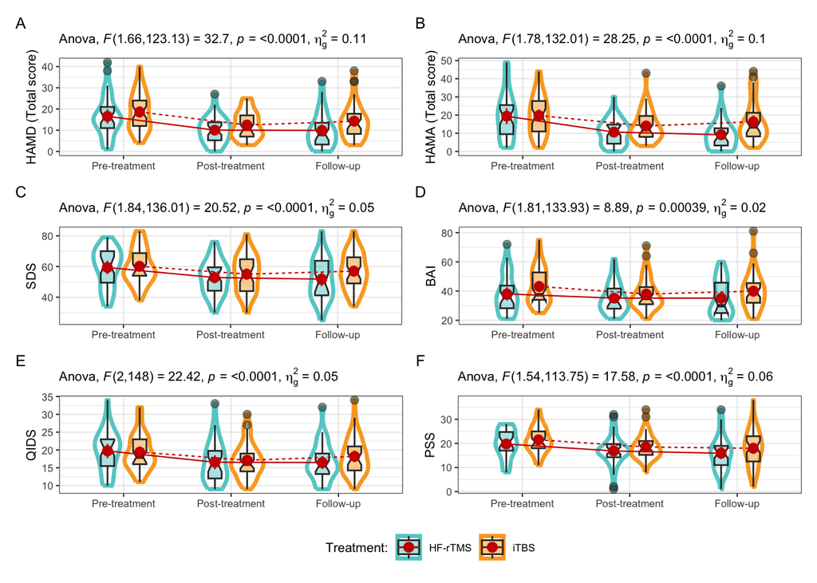

Figure 1: Outcome measures’ summaries of the per-protocol data.

Table 3

Table 3 Analyses of variance. A series of univariate mixed ANOVAs testing for null effects in a per-protocol analysis.

| Effect | *F* | *df*<sub>*n*</sub> | *df*<sub>*d*</sub> | *p* | *q* | sig. | η<sup>2</sup> |
| --- | --- | --- | --- | --- | --- | --- | --- |
| Self-rating Depression Scale |  |  |  |  |  |  |  |
| Treatment | 1.211 | 1.00 | 74.00 | .275 | .414 |  | 0.013 |
| Occasion | 20.522 | 1.84 | 136.01 | < .001 | < .001 | * | 0.048 |
| Treatment * Occasion | 2.524 | 1.84 | 136.01 | .088 | .158 |  | 0.006 |
| Quick Inventory of Depressive Symptomatology |  |  |  |  |  |  |  |
| Treatment | 0.350 | 1.00 | 74.00 | .556 | .676 |  | 0.004 |
| Occasion | 22.418 | 1.99 | 147.45 | < .001 | < .001 | * | 0.050 |
| Treatment * Occasion | 2.795 | 1.99 | 147.45 | .065 | .127 |  | 0.006 |
| Beck's Anxiety Scale |  |  |  |  |  |  |  |
| Treatment | 2.841 | 1.00 | 74.00 | .096 | .166 |  | 0.031 |
| Occasion | 8.889 | 1.81 | 133.93 | < .001 | .001 | * | 0.020 |
| Treatment * Occasion | 0.756 | 1.81 | 133.93 | .459 | .590 |  | 0.002 |
| Perceived Stress Scale |  |  |  |  |  |  |  |
| Treatment | 2.179 | 1.00 | 74.00 | .144 | .231 |  | 0.021 |
| Occasion | 17.580 | 1.54 | 113.75 | < .001 | < .001 | * | 0.062 |
| Treatment * Occasion | 0.057 | 1.54 | 113.75 | .904 | .928 |  | 0.000 |
| Chronotype Inventory |  |  |  |  |  |  |  |
| Treatment | 0.001 | 1.00 | 74.00 | .981 | .981 |  | 0.000 |
| Occasion | 0.723 | 1.87 | 138.17 | .478 | .597 |  | 0.001 |
| Treatment * Occasion | 0.192 | 1.87 | 138.17 | .811 | .890 |  | 0.000 |
| Hamilton's Depression Inventory - Total score |  |  |  |  |  |  |  |
| Treatment | 3.583 | 1.00 | 74.00 | .062 | .127 |  | 0.033 |
| Occasion | 32.700 | 1.66 | 123.13 | < .001 | < .001 | * | 0.112 |
| Treatment * Occasion | 1.062 | 1.66 | 123.13 | .339 | .462 |  | 0.004 |
| Hamilton's Depression Inventory - Anxiety |  |  |  |  |  |  |  |
| Treatment | 3.897 | 1.00 | 74.00 | .052 | .117 |  | 0.034 |
| Occasion | 25.758 | 1.78 | 131.40 | < .001 | < .001 | * | 0.106 |
| Treatment * Occasion | 1.258 | 1.78 | 131.40 | .285 | .414 |  | 0.006 |
| Hamilton's Depression Inventory - Weight Loss |  |  |  |  |  |  |  |
| Treatment | 0.082 | 1.00 | 74.00 | .776 | .873 |  | 0.001 |
| Occasion | 6.403 | 1.68 | 124.52 | .004 | .012 | * | 0.044 |
| Treatment * Occasion | 0.353 | 1.68 | 124.52 | .666 | .789 |  | 0.003 |
| Hamilton's Depression Inventory - Thought Disorders |  |  |  |  |  |  |  |
| Treatment | 0.590 | 1.00 | 74.00 | .445 | .589 |  | 0.005 |
| Occasion | 10.495 | 1.85 | 136.98 | < .001 | < .001 | * | 0.045 |
| Treatment * Occasion | 0.084 | 1.85 | 136.98 | .907 | .928 |  | 0.000 |
| Hamilton's Depression Inventory - Disturbed Circadian Rhythm |  |  |  |  |  |  |  |
| Treatment | 6.219 | 1.00 | 74.00 | .015 | .038 | * | 0.042 |
| Occasion | 4.494 | 1.84 | 136.49 | .015 | .038 | * | 0.028 |
| Treatment * Occasion | 1.107 | 1.84 | 136.49 | .330 | .462 |  | 0.007 |
| Hamilton's Depression Inventory - Retardation |  |  |  |  |  |  |  |
| Treatment | 0.130 | 1.00 | 74.00 | .719 | .830 |  | 0.001 |
| Occasion | 15.907 | 1.75 | 129.21 | < .001 | < .001 | * | 0.075 |
| Treatment * Occasion | 1.277 | 1.75 | 129.21 | .280 | .414 |  | 0.007 |
| Hamilton's Depression Inventory - Sleep Disorders |  |  |  |  |  |  |  |
| Treatment | 9.947 | 1.00 | 74.00 | .002 | .006 | * | 0.077 |
| Occasion | 14.796 | 1.90 | 140.25 | < .001 | < .001 | * | 0.070 |
| Treatment * Occasion | 0.136 | 1.90 | 140.25 | .863 | .925 |  | 0.001 |
| Hamilton's Anxiety Inventory - Total score |  |  |  |  |  |  |  |
| Treatment | 3.665 | 1.00 | 74.00 | .059 | .126 |  | 0.033 |
| Occasion | 28.251 | 1.78 | 132.01 | < .001 | < .001 | * | 0.104 |
| Treatment * Occasion | 4.980 | 1.78 | 132.01 | .011 | .031 | * | 0.020 |
| Hamilton's Anxiety Inventory - Somatization |  |  |  |  |  |  |  |
| Treatment | 2.410 | 1.00 | 74.00 | .125 | .208 |  | 0.021 |
| Occasion | 15.290 | 1.72 | 127.33 | < .001 | < .001 | * | 0.063 |
| Treatment * Occasion | 2.609 | 1.72 | 127.33 | .086 | .158 |  | 0.011 |
| Hamilton's Anxiety Inventory - Psychological Anxiety |  |  |  |  |  |  |  |
| Treatment | 4.016 | 1.00 | 74.00 | .049 | .116 |  | 0.034 |
| Occasion | 26.852 | 1.88 | 139.03 | < .001 | < .001 | * | 0.110 |
| Treatment * Occasion | 7.200 | 1.88 | 139.03 | .001 | .003 | * | 0.032 |

*F*: F statistic from a mixed analysis of variance; *df*<sub>*n*</sub>: numerator degrees of freedom of the F statistic; *df*<sub>*d*</sub>: denominator (residual) degrees of freedom the F statistic; *p*: nominal p-value; *q*: false discovery rate (FDR) adjusted p-value (i.e., the q-value); sig.: statistically significant effects after adjusting for 5% FDR; η<sup>2</sup>: generalised η-squared measure of effect size.

Table 4

Table 4 Response and remission rates. Frequency and rate of subjects' response and remissions per group.

|  | Percentage change T1 HF-rTMS | Percentage change T1 iTBS | Percentage change T2 HF-rTMS | Percentage change T2 iTBS | T1 HF-rTMS | T1 iTBS | T1 Stat. test | T2 HF-rTMS | T2 iTBS | T2 Stat. test |
| --- | --- | --- | --- | --- | --- | --- | --- | --- | --- | --- |
| Response Rate |  |  |  |  |  |  |  |  |  |  |
| SDS | 9.22 ± 18.22 | 8.08 ± 13.26 | 12.23 ± 15.19 | 4.15 ± 15.55 | 0 (0.0%) | 0 (0.0%) | χ2(1) = 0.03, p = .857 | 0 (0.0%) | 1 (2.4%) | χ2(1) = 0.00, p = 1.000 |
| PSS | 15.29 ± 26.19 | 11.73 ± 21.79 | 19.29 ± 28.58 | 13.51 ± 32.97 | 3 (8.8%) | 1 (2.4%) | χ2(1) = 0.78, p = .377 | 3 (8.8%) | 5 (11.9%) | χ2(1) = 0.07, p = .789 |
| BAI | 2.67 ± 27.97 | 10.17 ± 16.63 | 3.97 ± 31.14 | 5.72 ± 19.84 | 0 (0.0%) | 0 (0.0%) | χ2(1) = 3.18, p = .075 | 0 (0.0%) | 1 (2.4%) | χ2(1) = 0.00, p = 1.000 |
| QIDS | 15.15 ± 16.38 | 10.29 ± 19.52 | 14.78 ± 18.44 | 4.78 ± 20.04 | 1 (2.9%) | 0 (0.0%) | χ2(1) = 0.10, p = .753 | 0 (0.0%) | 0 (0.0%) | χ2(1) = 1.53, p = .216 |
| HAMA | 42.30 ± 24.76 | 7.00 ± 81.16 | 43.62 ± 49.11 | -4.99 ± 94.58 | 11 (32.4%) | 10 (23.8%) | χ2(1) = 0.00, p = .973 | 17 (50.0%) | 7 (16.7%) | χ2(1) = 7.87, p = .005 |
| HAMD | 29.43 ± 66.17 | 25.39 ± 41.15 | 32.04 ± 48.47 | 14.32 ± 49.79 | 13 (38.2%) | 8 (19.0%) | χ2(1) = 0.76, p = .384 | 14 (41.2%) | 9 (21.4%) | χ2(1) = 2.45, p = .117 |
| Remission Rate |  |  |  |  |  |  |  |  |  |  |
| SDS | - | - | - | - | 14 (41.2%) | 13 (31.0%) | χ2(1) = 0.50, p = .480 | 17 (50.0%) | 12 (28.6%) | χ2(1) = 3.59, p = .058 |
| PSS | - | - | - | - | 8 (23.5%) | 5 (11.9%) | χ2(1) = 1.74, p = .187 | 12 (35.3%) | 11 (26.2%) | χ2(1) = 0.33, p = .563 |
| BAI | - | - | - | - | 0 (0.0%) | 0 (0.0%) | χ2(1) = 3.18, p = .075 | 0 (0.0%) | 0 (0.0%) | χ2(1) = 1.53, p = .216 |
| QIDS | - | - | - | - | 0 (0.0%) | 0 (0.0%) | χ2(1) = 3.18, p = .075 | 0 (0.0%) | 0 (0.0%) | χ2(1) = 1.53, p = .216 |
| HAMA | - | - | - | - | 29 (85.3%) | 30 (71.4%) | χ2(1) = 0.98, p = .322 | 30 (88.2%) | 30 (71.4%) | χ2(1) = 3.09, p = .079 |
| HAMD | - | - | - | - | 12 (35.3%) | 12 (28.6%) | χ2(1) = 0.08, p = .779 | 14 (41.2%) | 8 (19.0%) | χ2(1) = 3.24, p = .072 |

## Intention-to-treat analysis

Results of the modified intention-to-treat analysis are presented in Table 9, Table 10, Table 11 and Table 12. Overall, the results are consistent with the per-protocol analysis presented above.

# Suplementary data

Table 5

Table 5 Outcomes description. Outcomes' descriptive statistics for the intention-to-treat analysis for the two groups after randomization.

|  | HF-rTMS Pre-intervention N | HF-rTMS Pre-intervention Score | HF-rTMS Post-intervention N | HF-rTMS Post-intervention Score | HF-rTMS Follow-up N | HF-rTMS Follow-up Score | iTBS Pre-intervention N | iTBS Pre-intervention Score | iTBS Post-intervention N | iTBS Post-intervention Score | iTBS Follow-up N | iTBS Follow-up Score |
| --- | --- | --- | --- | --- | --- | --- | --- | --- | --- | --- | --- | --- |
| Self-rating Depression Scale |  |  |  |  |  |  |  |  |  |  |  |  |
| Total score | 48 | 59.77 ± 12.50 | 42 | 52.52 ± 10.75 | 34 | 51.79 ± 13.21 | 60 | 60.60 ± 12.05 | 60 | 54.90 ± 11.64 | 45 | 57.16 ± 11.23 |
| Quick Inventory of Depressive Symptomatology |  |  |  |  |  |  |  |  |  |  |  |  |
| Total score | 48 | 19.75 ± 5.55 | 42 | 16.81 ± 5.45 | 34 | 16.47 ± 5.17 | 60 | 19.58 ± 5.48 | 60 | 16.93 ± 5.07 | 45 | 18.33 ± 5.20 |
| Beck's Anxiety Scale |  |  |  |  |  |  |  |  |  |  |  |  |
| Total score | 48 | 39.17 ± 13.22 | 42 | 35.45 ± 10.38 | 34 | 35.21 ± 12.37 | 60 | 43.82 ± 13.02 | 60 | 38.55 ± 11.05 | 45 | 40.44 ± 12.60 |
| Perceived Stress Scale |  |  |  |  |  |  |  |  |  |  |  |  |
| Total score | 48 | 20.10 ± 5.24 | 42 | 17.36 ± 6.31 | 34 | 15.91 ± 7.07 | 60 | 21.17 ± 5.53 | 60 | 18.85 ± 5.21 | 45 | 17.98 ± 7.30 |
| Chronotype Inventory |  |  |  |  |  |  |  |  |  |  |  |  |
| Total score | 48 | 52.44 ± 9.76 | 42 | 52.81 ± 9.44 | 34 | 53.65 ± 9.27 | 60 | 52.60 ± 11.08 | 60 | 53.08 ± 10.41 | 45 | 54.22 ± 9.55 |
| Hamilton's Depression Inventory |  |  |  |  |  |  |  |  |  |  |  |  |
| Total score | 48 | 17.19 ± 9.75 | 42 | 10.60 ± 6.58 | 34 | 9.91 ± 8.06 | 60 | 19.23 ± 8.65 | 55 | 12.09 ± 7.14 | 45 | 14.38 ± 8.19 |
| Anxiety | 48 | 5.79 ± 3.24 | 42 | 3.74 ± 2.68 | 34 | 3.24 ± 2.81 | 60 | 6.55 ± 3.57 | 55 | 3.98 ± 2.44 | 45 | 4.84 ± 2.84 |
| Weight Loss | 48 | 0.52 ± 1.20 | 42 | 0.14 ± 0.47 | 34 | 0.12 ± 0.69 | 60 | 0.47 ± 1.13 | 55 | 0.15 ± 0.49 | 45 | 0.29 ± 0.63 |
| Thought Disorders | 48 | 3.25 ± 2.89 | 42 | 2.10 ± 1.86 | 34 | 1.94 ± 2.20 | 60 | 3.67 ± 2.97 | 55 | 2.42 ± 2.52 | 45 | 2.42 ± 2.44 |
| Disturbed Circadian Rhythm | 48 | 1.33 ± 1.33 | 42 | 0.67 ± 0.95 | 34 | 0.79 ± 1.23 | 60 | 1.73 ± 1.35 | 55 | 1.27 ± 1.16 | 45 | 1.51 ± 1.41 |
| Retardation (Slowness) | 48 | 4.60 ± 2.82 | 42 | 3.29 ± 2.55 | 34 | 2.74 ± 2.64 | 60 | 4.68 ± 2.41 | 55 | 2.73 ± 1.75 | 45 | 3.40 ± 2.38 |
| Sleep Disorders | 48 | 1.79 ± 1.77 | 42 | 0.67 ± 1.00 | 34 | 1.09 ± 1.24 | 60 | 2.55 ± 1.82 | 55 | 1.40 ± 1.62 | 45 | 2.02 ± 2.20 |
| Hamilton's Anxiety Inventory |  |  |  |  |  |  |  |  |  |  |  |  |
| Total score | 48 | 19.58 ± 12.10 | 42 | 10.98 ± 7.43 | 34 | 9.18 ± 8.11 | 60 | 20.65 ± 10.67 | 55 | 13.55 ± 8.80 | 45 | 16.62 ± 10.91 |
| Somatization | 48 | 8.60 ± 6.73 | 42 | 4.62 ± 4.07 | 34 | 4.41 ± 4.51 | 60 | 9.13 ± 5.68 | 55 | 6.20 ± 4.59 | 45 | 7.38 ± 5.78 |
| Psychological Anxiety | 48 | 10.92 ± 6.11 | 42 | 6.17 ± 4.13 | 34 | 4.76 ± 3.96 | 60 | 11.07 ± 5.86 | 55 | 7.33 ± 4.85 | 45 | 9.22 ± 6.01 |

Table 6

Table 6 Paired comparisons. Main effects of the Occasion variable in a per-protocol analysis.

| Outcome | T1-minus-T0 *t* | T1-minus-T0 df | T1-minus-T0 *p* | T1-minus-T0 *d* | T1-minus-T0 ES | T2-minus-T0 *t* | T2-minus-T0 df | T2-minus-T0 *p* | T2-minus-T0 *d* | T2-minus-T0 ES | T2-minus-T1 *t* | T2-minus-T1 df | T2-minus-T1 *p* | T2-minus-T1 *d* | T2-minus-T1 ES |
| --- | --- | --- | --- | --- | --- | --- | --- | --- | --- | --- | --- | --- | --- | --- | --- |
| SDS | 5.634 | 75 | < .001 | 0.64 [0.41, 0.91] | moderate | 4.510 | 75 | < .001 | 0.51 [0.32, 0.72] | moderate | -0.683 | 75 | .497 | -0.08 [-0.34, 0.13] | negligible |
| QIDS | 6.235 | 75 | < .001 | 0.71 [0.48, 0.95] | moderate | 4.664 | 75 | < .001 | 0.53 [0.29, 0.80] | moderate | -1.302 | 75 | .197 | -0.15 [-0.35, 0.08] | negligible |
| BAI | 3.992 | 75 | < .001 | 0.45 [0.23, 0.68] | small | 2.812 | 75 | .006 | 0.32 [0.12, 0.57] | small | -1.337 | 75 | .185 | -0.15 [-0.38, 0.07] | negligible |
| PSS | 5.356 | 75 | < .001 | 0.61 [0.40, 0.85] | moderate | 4.545 | 75 | < .001 | 0.52 [0.32, 0.71] | moderate | 1.320 | 75 | .191 | 0.15 [-0.05, 0.37] | negligible |
| Chronotype | -0.873 | 75 | .386 | -0.10 [-0.31, 0.15] | negligible | -1.132 | 75 | .261 | -0.13 [-0.34, 0.10] | negligible | -0.491 | 75 | .625 | -0.06 [-0.31, 0.15] | negligible |
| HAMD (Total score) | 8.397 | 75 | < .001 | 0.95 [0.74, 1.25] | large | 5.271 | 75 | < .001 | 0.60 [0.38, 0.88] | moderate | -1.272 | 75 | .207 | -0.14 [-0.36, 0.06] | negligible |
| HAMD (Anxiety) | 6.573 | 75 | < .001 | 0.75 [0.53, 0.99] | moderate | 5.104 | 75 | < .001 | 0.58 [0.38, 0.82] | moderate | -1.157 | 75 | .251 | -0.13 [-0.38, 0.07] | negligible |
| HAMD (Weight Loss) | 3.332 | 75 | .001 | 0.38 [0.24, 0.54] | small | 2.474 | 75 | .016 | 0.28 [0.06, 0.53] | small | -0.435 | 75 | .665 | -0.05 [-0.25, 0.18] | negligible |
| HAMD (Thought Disorders) | 3.846 | 75 | < .001 | 0.44 [0.23, 0.71] | small | 3.707 | 75 | < .001 | 0.42 [0.19, 0.65] | small | 0.488 | 75 | .627 | 0.06 [-0.16, 0.29] | negligible |
| HAMD (Disturbed Circadian Rhythm) | 3.249 | 75 | .002 | 0.37 [0.14, 0.61] | small | 1.540 | 75 | .128 | 0.17 [-0.05, 0.40] | negligible | -1.193 | 75 | .237 | -0.14 [-0.37, 0.09] | negligible |
| HAMD (Retardation (Slowness)) | 6.549 | 75 | < .001 | 0.74 [0.49, 1.05] | moderate | 3.930 | 75 | < .001 | 0.45 [0.23, 0.68] | small | -0.691 | 75 | .492 | -0.08 [-0.29, 0.13] | negligible |
| HAMD (Sleep Disorders) | 5.685 | 75 | < .001 | 0.65 [0.45, 0.89] | moderate | 2.933 | 75 | .004 | 0.33 [0.12, 0.56] | small | -2.471 | 75 | .016 | -0.28 [-0.49, -0.07] | small |
| HAMA (Total score) | 6.352 | 75 | < .001 | 0.72 [0.45, 1.07] | moderate | 5.112 | 75 | < .001 | 0.58 [0.36, 0.87] | moderate | -0.701 | 75 | .486 | -0.08 [-0.30, 0.13] | negligible |
| HAMA (Somatization) | 4.736 | 75 | < .001 | 0.54 [0.30, 0.82] | moderate | 3.584 | 75 | < .001 | 0.41 [0.18, 0.68] | small | -1.099 | 75 | .275 | -0.12 [-0.37, 0.08] | negligible |
| HAMA (Psychological Anxiety) | 6.180 | 75 | < .001 | 0.70 [0.45, 1.04] | moderate | 5.013 | 75 | < .001 | 0.57 [0.33, 0.88] | moderate | -0.381 | 75 | .704 | -0.04 [-0.26, 0.17] | negligible |

HAMA: Hamilton’s Depression Inventory; SDS: Self-rating Depression Scale, QIDS: Quick Inventory of Depressive Symptomatology; HAMA: Hamilton’s Anxiety Inventory, BAI: Beck’s Anxiety Scale; PSS: Perceived Stress Scale; HF-rTMS: high frequency repetitive transcranial magnetic stimulation; iTBS: intermittent theta burst stimulation; *t*: test statistic; df: degrees of freedom; *p*: unadjusted p-value; *d*: Cohen’s d with Hedges correction with its 95% confidence interval; ES: verbal classification of the effect size point estimate.

Table 7

Table 7 Paired comparisons. Simple main effects of the Occasion variable in a per-protocol analysis.

| Outcome | T1-minus-T0 HF-rTMS *t* | T1-minus-T0 HF-rTMS df | T1-minus-T0 HF-rTMS *p* | T1-minus-T0 HF-rTMS *d* | T1-minus-T0 HF-rTMS ES | T1-minus-T0 iTBS *t* | T1-minus-T0 iTBS df | T1-minus-T0 iTBS *p* | T1-minus-T0 iTBS *d* | T1-minus-T0 iTBS ES | T2-minus-T0 HF-rTMS *t* | T2-minus-T0 HF-rTMS df | T2-minus-T0 HF-rTMS *p* | T2-minus-T0 HF-rTMS *d* | T2-minus-T0 HF-rTMS ES | T2-minus-T0 iTBS *t* | T2-minus-T0 iTBS df | T2-minus-T0 iTBS *p* | T2-minus-T0 iTBS *d* | T2-minus-T0 iTBS ES | T2-minus-T1 HF-rTMS *t* | T2-minus-T1 HF-rTMS df | T2-minus-T1 HF-rTMS *p* | T2-minus-T1 HF-rTMS *d* | T2-minus-T1 HF-rTMS ES | T2-minus-T1 iTBS *t* | T2-minus-T1 iTBS df | T2-minus-T1 iTBS *p* | T2-minus-T1 iTBS *d* | … |
| --- | --- | --- | --- | --- | --- | --- | --- | --- | --- | --- | --- | --- | --- | --- | --- | --- | --- | --- | --- | --- | --- | --- | --- | --- | --- | --- | --- | --- | --- | --- |
| SDS | 3.793 | 33 | < .001 | 0.64 [0.26, 1.13] | moderate | 4.193 | 41 | < .001 | 0.64 [0.38, 0.98] | moderate | 4.558 | 33 | < .001 | 0.76 [0.47, 1.10] | moderate | 2.089 | 41 | .043 | 0.32 [0.02, 0.58] | small | 0.819 | 33 | .418 | 0.14 [-0.23, 0.43] | negligible | -1.689 | 41 | .099 | -0.26 [-0.67, 0.04] | … |
| QIDS | 5.327 | 33 | < .001 | 0.89 [0.62, 1.26] | large | 3.742 | 41 | < .001 | 0.57 [0.28, 0.90] | moderate | 5.186 | 33 | < .001 | 0.87 [0.54, 1.33] | large | 1.951 | 41 | .058 | 0.30 [-0.01, 0.59] | small | 0.166 | 33 | .870 | 0.03 [-0.31, 0.41] | negligible | -1.702 | 41 | .096 | -0.26 [-0.57, 0.02] | … |
| BAI | 1.762 | 33 | .087 | 0.30 [-0.05, 0.70] | small | 3.890 | 41 | < .001 | 0.59 [0.34, 0.87] | moderate | 1.668 | 33 | .105 | 0.28 [-0.04, 0.73] | small | 2.279 | 41 | .028 | 0.35 [0.07, 0.63] | small | -0.034 | 33 | .973 | -0.01 [-0.34, 0.32] | negligible | -1.507 | 41 | .139 | -0.23 [-0.51, 0.10] | … |
| PSS | 3.584 | 33 | .001 | 0.60 [0.30, 0.98] | moderate | 3.935 | 41 | < .001 | 0.60 [0.32, 0.92] | moderate | 3.665 | 33 | < .001 | 0.61 [0.31, 0.98] | moderate | 2.938 | 41 | .005 | 0.45 [0.21, 0.68] | small | 1.250 | 33 | .220 | 0.21 [-0.13, 0.53] | small | 0.686 | 41 | .496 | 0.10 [-0.23, 0.42] | … |
| Chronotype | -0.616 | 33 | .542 | -0.10 [-0.47, 0.23] | negligible | -0.613 | 41 | .543 | -0.09 [-0.34, 0.25] | negligible | -0.404 | 33 | .689 | -0.07 [-0.46, 0.23] | negligible | -1.149 | 41 | .257 | -0.17 [-0.42, 0.13] | negligible | 0.089 | 33 | .930 | 0.01 [-0.36, 0.32] | negligible | -0.687 | 41 | .496 | -0.10 [-0.45, 0.20] | … |
| HAMD (Total score) | 6.071 | 33 | < .001 | 1.02 [0.76, 1.34] | large | 5.816 | 41 | < .001 | 0.88 [0.58, 1.31] | large | 4.177 | 33 | < .001 | 0.70 [0.43, 1.03] | moderate | 3.300 | 41 | .002 | 0.50 [0.19, 0.93] | small | 0.145 | 33 | .886 | 0.02 [-0.28, 0.39] | negligible | -1.747 | 41 | .088 | -0.26 [-0.56, 0.02] | … |
| HAMD (Anxiety) | 4.637 | 33 | < .001 | 0.78 [0.46, 1.18] | moderate | 4.855 | 41 | < .001 | 0.74 [0.46, 1.09] | moderate | 3.650 | 33 | < .001 | 0.61 [0.34, 0.95] | moderate | 3.536 | 41 | .001 | 0.54 [0.24, 0.87] | moderate | 0.663 | 33 | .512 | 0.11 [-0.25, 0.44] | negligible | -2.081 | 41 | .044 | -0.32 [-0.65, 0.01] | … |
| HAMD (Weight Loss) | 2.534 | 33 | .016 | 0.42 [0.15, 0.69] | small | 2.284 | 41 | .028 | 0.35 [0.23, 0.52] | small | 2.122 | 33 | .041 | 0.36 [0.02, 0.82] | small | 1.426 | 41 | .162 | 0.22 [-0.06, 0.46] | small | 0.387 | 33 | .701 | 0.06 [-0.21, 0.46] | negligible | -1.094 | 41 | .281 | -0.17 [-0.42, 0.12] | … |
| HAMD (Thought Disorders) | 3.002 | 33 | .005 | 0.50 [0.21, 0.82] | moderate | 2.500 | 41 | .016 | 0.38 [0.07, 0.79] | small | 2.451 | 33 | .020 | 0.41 [0.12, 0.73] | small | 2.784 | 41 | .008 | 0.42 [0.11, 0.77] | small | 0.438 | 33 | .664 | 0.07 [-0.22, 0.45] | negligible | 0.273 | 41 | .786 | 0.04 [-0.26, 0.33] | … |
| HAMD (Disturbed Circadian Rhythm) | 3.354 | 33 | .002 | 0.56 [0.25, 0.90] | moderate | 1.649 | 41 | .107 | 0.25 [-0.03, 0.57] | small | 2.098 | 33 | .044 | 0.35 [0.03, 0.71] | small | 0.263 | 41 | .794 | 0.04 [-0.26, 0.36] | negligible | -0.297 | 33 | .768 | -0.05 [-0.41, 0.28] | negligible | -1.219 | 41 | .230 | -0.18 [-0.51, 0.12] | … |
| HAMD (Retardation (Slowness)) | 4.398 | 33 | < .001 | 0.74 [0.48, 1.06] | moderate | 4.795 | 41 | < .001 | 0.73 [0.38, 1.22] | moderate | 3.716 | 33 | < .001 | 0.62 [0.38, 0.92] | moderate | 2.040 | 41 | .048 | 0.31 [0.02, 0.62] | small | 0.594 | 33 | .557 | 0.10 [-0.23, 0.41] | negligible | -1.285 | 41 | .206 | -0.19 [-0.50, 0.07] | … |
| HAMD (Sleep Disorders) | 3.432 | 33 | .002 | 0.58 [0.28, 0.90] | moderate | 4.540 | 41 | < .001 | 0.69 [0.38, 1.06] | moderate | 2.143 | 33 | .040 | 0.36 [0.05, 0.69] | small | 2.133 | 41 | .039 | 0.32 [0.05, 0.65] | small | -2.228 | 33 | .033 | -0.37 [-0.65, -0.08] | small | -1.472 | 41 | .149 | -0.22 [-0.49, 0.06] | … |
| HAMA (Total score) | 6.649 | 33 | < .001 | 1.11 [0.88, 1.54] | large | 3.376 | 41 | .002 | 0.51 [0.17, 0.97] | moderate | 5.622 | 33 | < .001 | 0.94 [0.72, 1.25] | large | 2.106 | 41 | .041 | 0.32 [0.04, 0.73] | small | 1.118 | 33 | .272 | 0.19 [-0.14, 0.53] | negligible | -1.971 | 41 | .056 | -0.30 [-0.59, -0.00] | … |
| HAMA (Somatization) | 5.019 | 33 | < .001 | 0.84 [0.62, 1.12] | large | 2.358 | 41 | .023 | 0.36 [0.06, 0.73] | small | 4.042 | 33 | < .001 | 0.68 [0.44, 0.98] | moderate | 1.355 | 41 | .183 | 0.21 [-0.08, 0.63] | small | 0.041 | 33 | .967 | 0.01 [-0.31, 0.34] | negligible | -1.538 | 41 | .132 | -0.23 [-0.58, 0.09] | … |
| HAMA (Psychological Anxiety) | 6.803 | 33 | < .001 | 1.14 [0.91, 1.52] | large | 3.101 | 41 | .003 | 0.47 [0.16, 0.90] | small | 6.491 | 33 | < .001 | 1.09 [0.83, 1.47] | large | 1.623 | 41 | .112 | 0.25 [-0.05, 0.67] | small | 1.549 | 33 | .131 | 0.26 [-0.06, 0.59] | small | -1.843 | 41 | .073 | -0.28 [-0.55, 0.02] | … |

HAMA: Hamilton’s Depression Inventory; SDS: Self-rating Depression Scale, QIDS: Quick Inventory of Depressive Symptomatology; HAMA: Hamilton’s Anxiety Inventory, BAI: Beck’s Anxiety Scale; PSS: Perceived Stress Scale; HF-rTMS: high frequency repetitive transcranial magnetic stimulation; iTBS: intermittent theta burst stimulation; *t*: test statistic; df: degrees of freedom; *p*: unadjusted p-value; *d*: Cohen’s d with Hedges correction with its 95% confidence interval; ES: verbal classification of the effect size point estimate.

Table 8

Table 8 Paired comparisons. Simple main effects of the Treatment variable in a per-protocol analysis.

| Outcome | T0 *t* | T0 df | T0 *p* | T0 *d* | T0 ES | T1 *t* | T1 df | T1 *p* | T1 *d* | T1 ES | T2 *t* | T2 df | T2 *p* | T2 *d* | T2 ES |
| --- | --- | --- | --- | --- | --- | --- | --- | --- | --- | --- | --- | --- | --- | --- | --- |
| SDS | -0.276 | 68 | .783 | -0.06 [-0.52, 0.40] | negligible | -0.847 | 73 | .400 | -0.19 [-0.63, 0.25] | negligible | -1.807 | 66 | .075 | -0.42 [-0.90, 0.03] | small |
| QIDS | 0.265 | 66 | .792 | 0.06 [-0.40, 0.52] | negligible | -0.458 | 65 | .648 | -0.11 [-0.55, 0.34] | negligible | -1.445 | 71 | .153 | -0.33 [-0.82, 0.10] | small |
| BAI | -1.712 | 69 | .091 | -0.39 [-0.89, 0.04] | small | -1.172 | 73 | .245 | -0.27 [-0.70, 0.16] | small | -1.667 | 71 | .100 | -0.38 [-0.87, 0.05] | small |
| PSS | -1.360 | 68 | .178 | -0.31 [-0.77, 0.10] | small | -1.182 | 61 | .242 | -0.27 [-0.72, 0.17] | small | -1.235 | 72 | .221 | -0.28 [-0.75, 0.14] | small |
| Chronotype | 0.045 | 73 | .964 | 0.01 [-0.46, 0.49] | negligible | 0.059 | 73 | .953 | 0.01 [-0.44, 0.44] | negligible | -0.183 | 72 | .855 | -0.04 [-0.49, 0.41] | negligible |
| HAMD (Total score) | -0.968 | 68 | .337 | -0.22 [-0.75, 0.23] | small | -1.656 | 71 | .102 | -0.38 [-0.83, 0.07] | small | -2.322 | 71 | .023 | -0.53 [-1.06, -0.04] | moderate |
| HAMD (Anxiety) | -1.467 | 74 | .147 | -0.33 [-0.79, 0.13] | small | -0.950 | 69 | .345 | -0.22 [-0.66, 0.23] | small | -2.399 | 72 | .019 | -0.55 [-1.05, -0.09] | moderate |
| HAMD (Weight Loss) | 0.023 | 71 | .981 | 0.01 [-0.38, 0.59] | negligible | 0.292 | 68 | .771 | 0.07 [-0.37, 0.49] | negligible | -0.972 | 65 | .335 | -0.22 [-0.79, 0.20] | small |
| HAMD (Thought Disorders) | -0.357 | 69 | .722 | -0.08 [-0.60, 0.38] | negligible | -0.795 | 74 | .429 | -0.18 [-0.59, 0.26] | negligible | -0.815 | 73 | .418 | -0.18 [-0.68, 0.27] | negligible |
| HAMD (Disturbed Circadian Rhythm) | -0.847 | 71 | .400 | -0.19 [-0.67, 0.25] | negligible | -2.141 | 74 | .036 | -0.49 [-1.01, -0.06] | small | -2.563 | 74 | .012 | -0.58 [-1.10, -0.13] | moderate |
| HAMD (Retardation (Slowness)) | 0.193 | 64 | .847 | 0.04 [-0.45, 0.51] | negligible | 0.231 | 58 | .818 | 0.05 [-0.38, 0.51] | negligible | -1.180 | 68 | .242 | -0.27 [-0.75, 0.18] | small |
| HAMD (Sleep Disorders) | -2.612 | 72 | .011 | -0.59 [-1.09, -0.14] | moderate | -3.273 | 67 | .002 | -0.73 [-1.18, -0.34] | moderate | -2.128 | 67 | .037 | -0.47 [-0.90, -0.04] | small |
| HAMA (Total score) | -0.131 | 65 | .896 | -0.03 [-0.49, 0.46] | negligible | -1.921 | 74 | .059 | -0.43 [-0.86, 0.00] | small | -3.265 | 73 | .002 | -0.73 [-1.21, -0.30] | moderate |
| HAMA (Somatization) | -0.048 | 62 | .962 | -0.01 [-0.47, 0.46] | negligible | -1.929 | 74 | .058 | -0.44 [-0.91, 0.01] | small | -2.342 | 74 | .022 | -0.53 [-0.99, -0.12] | moderate |
| HAMA (Psychological Anxiety) | 0.192 | 70 | .848 | 0.04 [-0.44, 0.52] | negligible | -1.866 | 73 | .066 | -0.42 [-0.85, 0.01] | small | -3.760 | 71 | < .001 | -0.84 [-1.31, -0.42] | large |

HAMA: Hamilton’s Depression Inventory; SDS: Self-rating Depression Scale, QIDS: Quick Inventory of Depressive Symptomatology; HAMA: Hamilton’s Anxiety Inventory, BAI: Beck’s Anxiety Scale; PSS: Perceived Stress Scale; HF-rTMS: high frequency repetitive transcranial magnetic stimulation; iTBS: intermittent theta burst stimulation; *t*: test statistic; df: degrees of freedom; *p*: unadjusted p-value; *d*: Cohen’s d with Hedges correction with its 95% confidence interval; ES: verbal classification of the effect size point estimate.

Table 9

Table 9 Analyses of variance. A series of univariate ANOVAs testing for null effects in an intention-to-treat analysis.

| Effect | *F* | *df*<sub>*n*</sub> | *df*<sub>*d*</sub> | *p* | *q* | sig. |
| --- | --- | --- | --- | --- | --- | --- |
| Self-rating Depression Scale |  |  |  |  |  |  |
| Treatment | 1.824 | 1.00 | 107.01 | .180 | .279 |  |
| Occasion | 31.863 | 2.00 | 181.29 | < .001 | < .001 | * |
| Treatment * Occasion | 2.081 | 2.00 | 181.29 | .128 | .221 |  |
| Quick Inventory of Depressive Symptomatology |  |  |  |  |  |  |
| Treatment | 0.376 | 1.00 | 107.42 | .541 | .680 |  |
| Occasion | 28.874 | 2.00 | 181.41 | < .001 | < .001 | * |
| Treatment * Occasion | 2.398 | 2.00 | 181.41 | .094 | .176 |  |
| Beck's Anxiety Scale |  |  |  |  |  |  |
| Treatment | 3.648 | 1.00 | 106.81 | .059 | .126 |  |
| Occasion | 13.476 | 2.00 | 180.76 | < .001 | < .001 | * |
| Treatment * Occasion | 0.479 | 2.00 | 180.76 | .620 | .716 |  |
| Perceived Stress Scale |  |  |  |  |  |  |
| Treatment | 1.824 | 1.00 | 109.19 | .180 | .279 |  |
| Occasion | 20.975 | 2.00 | 185.16 | < .001 | < .001 | * |
| Treatment * Occasion | 0.117 | 2.00 | 185.16 | .889 | .953 |  |
| Chronotype Inventory |  |  |  |  |  |  |
| Treatment | 0.121 | 1.00 | 106.57 | .729 | .800 |  |
| Occasion | 0.940 | 2.00 | 178.38 | .392 | .519 |  |
| Treatment * Occasion | 0.548 | 2.00 | 178.38 | .579 | .704 |  |
| Hamilton's Depression Inventory - Total score |  |  |  |  |  |  |
| Treatment | 3.218 | 1.00 | 104.60 | .076 | .148 |  |
| Occasion | 50.327 | 2.00 | 176.39 | < .001 | < .001 | * |
| Treatment * Occasion | 1.020 | 2.00 | 176.39 | .363 | .495 |  |
| Hamilton's Depression Inventory - Anxiety |  |  |  |  |  |  |
| Treatment | 2.244 | 1.00 | 104.87 | .137 | .229 |  |
| Occasion | 35.114 | 2.00 | 178.81 | < .001 | < .001 | * |
| Treatment * Occasion | 1.481 | 2.00 | 178.81 | .230 | .334 |  |
| Hamilton's Depression Inventory - Weight Loss |  |  |  |  |  |  |
| Treatment | 0.144 | 1.00 | 99.66 | .705 | .793 |  |
| Occasion | 6.412 | 2.00 | 182.76 | .002 | .006 | * |
| Treatment * Occasion | 0.486 | 2.00 | 182.76 | .616 | .716 |  |
| Hamilton's Depression Inventory - Thought Disorders |  |  |  |  |  |  |
| Treatment | 0.977 | 1.00 | 101.87 | .325 | .457 |  |
| Occasion | 17.072 | 2.00 | 174.24 | < .001 | < .001 | * |
| Treatment * Occasion | 0.022 | 2.00 | 174.24 | .978 | .996 |  |
| Hamilton's Depression Inventory - Disturbed Circadian Rhythm |  |  |  |  |  |  |
| Treatment | 10.662 | 1.00 | 103.91 | .001 | .005 | * |
| Occasion | 7.149 | 2.00 | 185.30 | .001 | .004 | * |
| Treatment * Occasion | 0.611 | 2.00 | 185.30 | .544 | .680 |  |
| Hamilton's Depression Inventory - Retardation |  |  |  |  |  |  |
| Treatment | 0.008 | 1.00 | 104.92 | .929 | .972 |  |
| Occasion | 23.222 | 2.00 | 181.01 | < .001 | < .001 | * |
| Treatment * Occasion | 1.574 | 2.00 | 181.01 | .210 | .315 |  |
| Hamilton's Depression Inventory - Sleep Disorders |  |  |  |  |  |  |
| Treatment | 7.330 | 1.00 | 104.55 | .008 | .021 | * |
| Occasion | 20.549 | 2.00 | 179.11 | < .001 | < .001 | * |
| Treatment * Occasion | 0.004 | 2.00 | 179.11 | .996 | .996 |  |
| Hamilton's Anxiety Inventory - Total score |  |  |  |  |  |  |
| Treatment | 4.329 | 1.00 | 104.92 | .040 | .092 |  |
| Occasion | 43.169 | 2.00 | 177.26 | < .001 | < .001 | * |
| Treatment * Occasion | 4.545 | 2.00 | 177.26 | .012 | .030 | * |
| Hamilton's Anxiety Inventory - Somatization |  |  |  |  |  |  |
| Treatment | 3.299 | 1.00 | 104.65 | .072 | .148 |  |
| Occasion | 25.328 | 2.00 | 177.55 | < .001 | < .001 | * |
| Treatment * Occasion | 2.187 | 2.00 | 177.55 | .115 | .207 |  |
| Hamilton's Anxiety Inventory - Psychological Anxiety |  |  |  |  |  |  |
| Treatment | 4.277 | 1.00 | 104.18 | .041 | .092 |  |
| Occasion | 39.673 | 2.00 | 177.85 | < .001 | < .001 | * |
| Treatment * Occasion | 6.446 | 2.00 | 177.85 | .002 | .006 | * |

*F*: F statistic from a mixed analysis of variance; *df*<sub>*n*</sub>: numerator degrees of freedom of the F statistic; *df*<sub>*d*</sub>: denominator (residual) degrees of freedom the F statistic; *p*: nominal p-value; *q*: false discovery rate (FDR) adjusted p-value (i.e., the q-value); sig.: statistically significant effects after adjusting for 5% FDR.

Table 10

Table 10 Paired comparisons. Main effects of the Occasion variable in an intention-to-treat analysis.

| Outcome | T1-minus-T0 Estimate [95% CI] | T1-minus-T0 *t* | T1-minus-T0 df | T1-minus-T0 *p* | T2-minus-T0 Estimate [95% CI] | T2-minus-T0 *t* | T2-minus-T0 df | T2-minus-T0 *p* | T2-minus-T1 Estimate [95% CI] | T2-minus-T1 *t* | T2-minus-T1 df | T2-minus-T1 *p* |
| --- | --- | --- | --- | --- | --- | --- | --- | --- | --- | --- | --- | --- |
| SDS | -6.68 [-8.83, -4.53] | -7.335 | 180.45 | < .001 | -6.10 [-8.45, -3.74] | -6.120 | 183.39 | < .001 | 0.58 [-1.78, 2.95] | 0.581 | 180.66 | .831 |
| QIDS | -2.85 [-3.78, -1.92] | -7.240 | 180.24 | < .001 | -2.30 [-3.32, -1.28] | -5.327 | 182.94 | < .001 | 0.55 [-0.47, 1.58] | 1.281 | 180.37 | .408 |
| BAI | -4.49 [-6.60, -2.38] | -5.022 | 180.20 | < .001 | -3.37 [-5.68, -1.05] | -3.440 | 182.84 | .002 | 1.12 [-1.20, 3.45] | 1.143 | 180.30 | .489 |
| PSS | -2.52 [-3.79, -1.24] | -4.651 | 181.60 | < .001 | -3.61 [-5.01, -2.22] | -6.116 | 186.06 | < .001 | -1.10 [-2.50, 0.31] | -1.847 | 182.52 | .157 |
| Chronotype | 0.21 [-0.78, 1.21] | 0.508 | 178.10 | .868 | 0.63 [-0.46, 1.73] | 1.365 | 178.85 | .361 | 0.42 [-0.68, 1.52] | 0.902 | 177.94 | .640 |
| HAMD (Total score) | -6.77 [-8.49, -5.05] | -9.292 | 177.44 | < .001 | -5.92 [-7.77, -4.06] | -7.528 | 180.79 | < .001 | 0.86 [-1.03, 2.74] | 1.072 | 177.57 | .533 |
| HAMD (Anxiety) | -2.28 [-2.99, -1.58] | -7.672 | 178.72 | < .001 | -2.06 [-2.82, -1.30] | -6.432 | 183.31 | < .001 | 0.22 [-0.55, 0.99] | 0.681 | 179.57 | .775 |
| HAMD (Weight Loss) | -0.36 [-0.61, -0.10] | -3.338 | 182.38 | .003 | -0.30 [-0.57, -0.03] | -2.641 | 191.97 | .024 | 0.05 [-0.22, 0.33] | 0.472 | 187.58 | .885 |
| HAMD (Thought Disorders) | -1.20 [-1.77, -0.64] | -5.032 | 177.81 | < .001 | -1.26 [-1.87, -0.65] | -4.900 | 181.49 | < .001 | -0.06 [-0.68, 0.56] | -0.229 | 178.10 | .972 |
| HAMD (Disturbed Circadian Rhythm) | -0.57 [-0.93, -0.21] | -3.696 | 181.86 | < .001 | -0.39 [-0.78, 0.00] | -2.352 | 190.62 | .051 | 0.18 [-0.22, 0.58] | 1.080 | 186.24 | .528 |
| HAMD (Retardation (Slowness)) | -1.60 [-2.22, -0.98] | -6.120 | 179.78 | < .001 | -1.52 [-2.18, -0.85] | -5.403 | 185.62 | < .001 | 0.08 [-0.59, 0.76] | 0.286 | 181.54 | .956 |
| HAMD (Sleep Disorders) | -1.10 [-1.51, -0.69] | -6.389 | 179.04 | < .001 | -0.61 [-1.05, -0.17] | -3.293 | 183.99 | .003 | 0.49 [0.04, 0.94] | 2.599 | 180.13 | .027 |
| HAMA (Total score) | -7.68 [-9.85, -5.52] | -8.388 | 177.80 | < .001 | -7.22 [-9.56, -4.89] | -7.315 | 181.47 | < .001 | 0.46 [-1.91, 2.83] | 0.458 | 178.09 | .891 |
| HAMA (Somatization) | -3.39 [-4.59, -2.18] | -6.647 | 178.13 | < .001 | -2.88 [-4.17, -1.58] | -5.237 | 182.12 | < .001 | 0.51 [-0.81, 1.83] | 0.917 | 178.60 | .630 |
| HAMA (Psychological Anxiety) | -4.14 [-5.38, -2.90] | -7.904 | 178.56 | < .001 | -4.06 [-5.40, -2.73] | -7.195 | 182.99 | < .001 | 0.08 [-1.27, 1.44] | 0.142 | 179.30 | .989 |

HAMA: Hamilton’s Depression Inventory; SDS: Self-rating Depression Scale, QIDS: Quick Inventory of Depressive Symptomatology; HAMA: Hamilton’s Anxiety Inventory, BAI: Beck’s Anxiety Scale; PSS: Perceived Stress Scale; HF-rTMS: high frequency repetitive transcranial magnetic stimulation; iTBS: intermittent theta burst stimulation; *Estimate [95% CI]*: Estimated difference with its 95% confidence interval; *t*: test statistic; df: degrees of freedom; *p*: unadjusted p-value.

Table 11

Table 11 Paired comparisons. Simple main effects of the Occasion variable in an intention-to-treat analysis.

| Outcome | T1-minus-T0 HF-rTMS Estimate [95% CI] | T1-minus-T0 HF-rTMS *t* | T1-minus-T0 HF-rTMS df | T1-minus-T0 HF-rTMS *p* | T1-minus-T0 iTBS Estimate [95% CI] | T1-minus-T0 iTBS *t* | T1-minus-T0 iTBS df | T1-minus-T0 iTBS *p* | T2-minus-T0 HF-rTMS Estimate [95% CI] | T2-minus-T0 HF-rTMS *t* | T2-minus-T0 HF-rTMS df | T2-minus-T0 HF-rTMS *p* | T2-minus-T0 iTBS Estimate [95% CI] | T2-minus-T0 iTBS *t* | T2-minus-T0 iTBS df | T2-minus-T0 iTBS *p* | T2-minus-T1 HF-rTMS Estimate [95% CI] | T2-minus-T1 HF-rTMS *t* | T2-minus-T1 HF-rTMS df | T2-minus-T1 HF-rTMS *p* | T2-minus-T1 iTBS Estimate [95% CI] | T2-minus-T1 iTBS *t* | T2-minus-T1 iTBS df | T2-minus-T1 iTBS *p* |
| --- | --- | --- | --- | --- | --- | --- | --- | --- | --- | --- | --- | --- | --- | --- | --- | --- | --- | --- | --- | --- | --- | --- | --- | --- |
| SDS | -7.66 [-10.95, -4.37] | -5.504 | 182.75 | < .001 | -5.70 [-8.48, -2.92] | -4.851 | 177.26 | < .001 | -8.12 [-11.68, -4.57] | -5.396 | 185.02 | < .001 | -4.07 [-7.16, -0.99] | -3.119 | 181.24 | .006 | -0.46 [-4.05, 3.12] | -0.305 | 180.23 | .950 | 1.63 [-1.46, 4.71] | 1.244 | 181.24 | .429 |
| QIDS | -3.05 [-4.48, -1.63] | -5.071 | 182.41 | < .001 | -2.65 [-3.85, -1.45] | -5.217 | 177.22 | < .001 | -3.22 [-4.75, -1.68] | -4.936 | 184.48 | < .001 | -1.38 [-2.71, -0.04] | -2.440 | 180.90 | .041 | -0.16 [-1.71, 1.39] | -0.247 | 179.97 | .967 | 1.27 [-0.06, 2.61] | 2.250 | 180.90 | .066 |
| BAI | -3.71 [-6.94, -0.48] | -2.717 | 182.34 | .020 | -5.27 [-7.99, -2.54] | -4.568 | 177.22 | < .001 | -3.38 [-6.87, 0.12] | -2.283 | 184.36 | .061 | -3.36 [-6.39, -0.33] | -2.618 | 180.83 | .026 | 0.34 [-3.18, 3.86] | 0.227 | 179.91 | .972 | 1.91 [-1.12, 4.94] | 1.488 | 180.83 | .299 |
| PSS | -2.71 [-4.66, -0.76] | -3.288 | 184.56 | .003 | -2.32 [-3.97, -0.66] | -3.314 | 177.52 | .003 | -3.88 [-5.98, -1.77] | -4.350 | 188.10 | < .001 | -3.35 [-5.18, -1.52] | -4.319 | 183.38 | < .001 | -1.16 [-3.29, 0.97] | -1.291 | 181.88 | .402 | -1.03 [-2.86, 0.80] | -1.330 | 183.38 | .380 |
| Chronotype | -0.05 [-1.58, 1.48] | -0.084 | 178.87 | .996 | 0.48 [-0.80, 1.77] | 0.890 | 177.02 | .647 | 0.16 [-1.50, 1.81] | 0.222 | 179.41 | .973 | 1.11 [-0.32, 2.54] | 1.832 | 178.10 | .162 | 0.21 [-1.45, 1.87] | 0.299 | 177.83 | .952 | 0.63 [-0.81, 2.06] | 1.035 | 178.10 | .556 |
| HAMD (Total score) | -6.59 [-9.19, -4.00] | -6.010 | 179.13 | < .001 | -6.95 [-9.22, -4.68] | -7.243 | 175.25 | < .001 | -6.82 [-9.62, -4.02] | -5.753 | 182.29 | < .001 | -5.01 [-7.45, -2.57] | -4.856 | 178.82 | < .001 | -0.23 [-3.06, 2.60] | -0.189 | 176.51 | .981 | 1.94 [-0.56, 4.43] | 1.835 | 178.94 | .161 |
| HAMD (Anxiety) | -1.99 [-3.05, -0.93] | -4.444 | 180.63 | < .001 | -2.58 [-3.50, -1.65] | -6.569 | 176.24 | < .001 | -2.32 [-3.46, -1.18] | -4.813 | 185.05 | < .001 | -1.80 [-2.79, -0.80] | -4.267 | 181.04 | < .001 | -0.33 [-1.49, 0.82] | -0.684 | 178.18 | .773 | 0.78 [-0.24, 1.80] | 1.809 | 181.37 | .170 |
| HAMD (Weight Loss) | -0.39 [-0.77, -0.01] | -2.455 | 184.32 | .040 | -0.32 [-0.65, 0.01] | -2.262 | 179.91 | .064 | -0.41 [-0.82, -0.01] | -2.408 | 193.94 | .045 | -0.19 [-0.54, 0.17] | -1.260 | 189.42 | .419 | -0.02 [-0.43, 0.39] | -0.112 | 185.09 | .993 | 0.13 [-0.23, 0.49] | 0.844 | 190.86 | .676 |
| HAMD (Thought Disorders) | -1.19 [-2.04, -0.34] | -3.310 | 179.57 | .003 | -1.21 [-1.96, -0.47] | -3.859 | 175.52 | < .001 | -1.30 [-2.22, -0.39] | -3.356 | 183.07 | .003 | -1.22 [-2.02, -0.42] | -3.607 | 179.42 | .001 | -0.11 [-1.04, 0.81] | -0.288 | 176.95 | .955 | -0.01 [-0.82, 0.81] | -0.019 | 179.59 | 1.000 |
| HAMD (Disturbed Circadian Rhythm) | -0.68 [-1.23, -0.13] | -2.932 | 183.86 | .011 | -0.46 [-0.94, 0.02] | -2.263 | 179.30 | .064 | -0.57 [-1.15, 0.02] | -2.278 | 192.61 | .061 | -0.21 [-0.72, 0.30] | -0.969 | 188.05 | .597 | 0.11 [-0.49, 0.71] | 0.448 | 183.91 | .895 | 0.25 [-0.27, 0.77] | 1.127 | 189.30 | .498 |
| HAMD (Retardation (Slowness)) | -1.31 [-2.24, -0.39] | -3.349 | 181.81 | .003 | -1.88 [-2.70, -1.07] | -5.463 | 177.17 | < .001 | -1.73 [-2.73, -0.73] | -4.099 | 187.51 | < .001 | -1.30 [-2.17, -0.43] | -3.520 | 183.16 | .002 | -0.42 [-1.43, 0.60] | -0.974 | 179.85 | .594 | 0.58 [-0.31, 1.47] | 1.541 | 183.74 | .274 |
| HAMD (Sleep Disorders) | -1.09 [-1.70, -0.47] | -4.189 | 181.00 | < .001 | -1.12 [-1.66, -0.58] | -4.914 | 176.51 | < .001 | -0.61 [-1.27, 0.05] | -2.172 | 185.78 | .079 | -0.62 [-1.19, -0.04] | -2.519 | 181.65 | .034 | 0.48 [-0.19, 1.15] | 1.690 | 178.66 | .212 | 0.50 [-0.09, 1.09] | 2.014 | 182.05 | .112 |
| HAMA (Total score) | -8.45 [-11.70, -5.19] | -6.125 | 179.56 | < .001 | -6.92 [-9.77, -4.07] | -5.738 | 175.52 | < .001 | -10.15 [-13.67, -6.63] | -6.816 | 183.05 | < .001 | -4.30 [-7.37, -1.23] | -3.313 | 179.41 | .003 | -1.70 [-5.26, 1.85] | -1.132 | 176.94 | .495 | 2.62 [-0.51, 5.76] | 1.978 | 179.58 | .121 |
| HAMA (Somatization) | -3.91 [-5.73, -2.10] | -5.102 | 179.95 | < .001 | -2.86 [-4.45, -1.28] | -4.263 | 175.77 | < .001 | -4.02 [-5.98, -2.07] | -4.858 | 183.76 | < .001 | -1.73 [-3.44, -0.02] | -2.396 | 179.98 | .046 | -0.11 [-2.09, 1.87] | -0.130 | 177.37 | .991 | 1.13 [-0.61, 2.88] | 1.535 | 180.20 | .277 |
| HAMA (Psychological Anxiety) | -4.67 [-6.53, -2.80] | -5.920 | 180.45 | < .001 | -3.62 [-5.25, -1.98] | -5.237 | 176.11 | < .001 | -6.05 [-8.06, -4.04] | -7.116 | 184.71 | < .001 | -2.07 [-3.82, -0.31] | -2.787 | 180.75 | .016 | -1.39 [-3.42, 0.65] | -1.609 | 177.96 | .244 | 1.55 [-0.24, 3.34] | 2.042 | 181.05 | .105 |

HAMA: Hamilton’s Depression Inventory; SDS: Self-rating Depression Scale, QIDS: Quick Inventory of Depressive Symptomatology; HAMA: Hamilton’s Anxiety Inventory, BAI: Beck’s Anxiety Scale; PSS: Perceived Stress Scale; HF-rTMS: high frequency repetitive transcranial magnetic stimulation; iTBS: intermittent theta burst stimulation; *Estimate [95% CI]*: Estimated difference with its 95% confidence interval; *t*: test statistic; df: degrees of freedom; *p*: unadjusted p-value.

Table 12

Table 12 Paired comparisons. Simple main effects of the Treatment variable in an intention-to-treat analysis.

| Outcome | T0 Estimate [95% CI] | T0 *t* | T0 df | T0 *p* | T1 Estimate [95% CI] | T1 *t* | T1 df | T1 *p* | T2 Estimate [95% CI] | T2 *t* | T2 df | T2 *p* |
| --- | --- | --- | --- | --- | --- | --- | --- | --- | --- | --- | --- | --- |
| SDS | 0.83 [-3.72, 5.38] | 0.360 | 152.30 | .719 | 2.79 [-1.84, 7.42] | 1.189 | 160.66 | .236 | 4.88 [-0.02, 9.78] | 1.965 | 187.98 | .051 |
| QIDS | -0.17 [-2.20, 1.87] | -0.162 | 148.54 | .872 | 0.24 [-1.84, 2.31] | 0.225 | 156.50 | .822 | 1.67 [-0.51, 3.85] | 1.509 | 182.41 | .133 |
| BAI | 4.65 [-0.01, 9.31] | 1.973 | 147.71 | .050 | 3.10 [-1.64, 7.84] | 1.290 | 155.58 | .199 | 4.67 [-0.32, 9.66] | 1.846 | 181.16 | .067 |
| PSS | 1.06 [-1.23, 3.36] | 0.914 | 175.73 | .362 | 1.46 [-0.89, 3.81] | 1.224 | 185.54 | .222 | 1.59 [-0.94, 4.12] | 1.240 | 218.12 | .216 |
| Chronotype | 0.16 [-3.70, 4.02] | 0.083 | 117.75 | .934 | 0.70 [-3.18, 4.58] | 0.357 | 120.63 | .722 | 1.12 [-2.84, 5.07] | 0.559 | 129.24 | .577 |
| HAMD (Total score) | 2.05 [-1.10, 5.19] | 1.283 | 168.56 | .201 | 1.69 [-1.57, 4.95] | 1.023 | 182.73 | .308 | 3.85 [0.39, 7.31] | 2.197 | 209.48 | .029 |
| HAMD (Anxiety) | 0.76 [-0.39, 1.90] | 1.306 | 190.45 | .193 | 0.17 [-1.02, 1.36] | 0.284 | 205.10 | .777 | 1.28 [0.00, 2.57] | 1.977 | 232.27 | .049 |
| HAMD (Weight Loss) | -0.05 [-0.38, 0.27] | -0.331 | 258.74 | .741 | 0.02 [-0.32, 0.36] | 0.115 | 263.76 | .908 | 0.17 [-0.21, 0.54] | 0.888 | 272.53 | .375 |
| HAMD (Thought Disorders) | 0.42 [-0.58, 1.41] | 0.826 | 174.52 | .410 | 0.39 [-0.64, 1.43] | 0.750 | 189.02 | .454 | 0.50 [-0.60, 1.60] | 0.895 | 216.30 | .372 |
| HAMD (Disturbed Circadian Rhythm) | 0.40 [-0.08, 0.88] | 1.647 | 250.39 | .101 | 0.62 [0.11, 1.12] | 2.411 | 257.33 | .017 | 0.75 [0.20, 1.31] | 2.677 | 269.47 | .008 |
| HAMD (Retardation (Slowness)) | 0.08 [-0.85, 1.00] | 0.169 | 210.77 | .866 | -0.49 [-1.46, 0.48] | -0.993 | 224.16 | .322 | 0.51 [-0.54, 1.56] | 0.960 | 248.42 | .338 |
| HAMD (Sleep Disorders) | 0.76 [0.11, 1.41] | 2.312 | 196.44 | .022 | 0.73 [0.05, 1.40] | 2.125 | 210.88 | .035 | 0.75 [0.02, 1.48] | 2.036 | 237.49 | .043 |
| HAMA (Total score) | 1.07 [-2.76, 4.89] | 0.551 | 174.37 | .583 | 2.59 [-1.37, 6.55] | 1.289 | 188.87 | .199 | 6.92 [2.70, 11.14] | 3.231 | 216.13 | .001 |
| HAMA (Somatization) | 0.53 [-1.53, 2.59] | 0.506 | 180.01 | .613 | 1.58 [-0.56, 3.72] | 1.454 | 194.69 | .147 | 2.82 [0.53, 5.11] | 2.430 | 222.16 | .016 |
| HAMA (Psychological Anxiety) | 0.15 [-1.89, 2.19] | 0.145 | 187.62 | .885 | 1.20 [-0.93, 3.33] | 1.113 | 202.32 | .267 | 4.14 [1.85, 6.42] | 3.573 | 229.66 | < .001 |

HAMA: Hamilton’s Depression Inventory; SDS: Self-rating Depression Scale, QIDS: Quick Inventory of Depressive Symptomatology; HAMA: Hamilton’s Anxiety Inventory, BAI: Beck’s Anxiety Scale; PSS: Perceived Stress Scale; HF-rTMS: high frequency repetitive transcranial magnetic stimulation; iTBS: intermittent theta burst stimulation; *Estimate [95% CI]*: Estimated difference with its 95% confidence interval; *t*: test statistic; df: degrees of freedom; *p*: unadjusted p-value.

## References

Bates, D., Mächler, M., Bolker, B., & Walker, S. (2015). Fitting linear mixed-effects models using lme4. *Journal of Statistical Software*, *67*(1), 1–48. https://doi.org/10.18637/jss.v067.i01

Benjamini, Y., & Yekutieli, D. (2001). The control of the false discovery rate in multiple testing under dependency. *The Annals of Statistics*, *29*(4), 1165–1188. http://www.jstor.org/stable/2674075

Kassambara, A. (2023). *Rstatix: Pipe-friendly framework for basic statistical tests*. https://CRAN.R-project.org/package=rstatix

Kuznetsova, A., Brockhoff, P. B., & Christensen, R. H. B. (2017). lmerTest package: Tests in linear mixed effects models. *Journal of Statistical Software*, *82*(13), 1–26. https://doi.org/10.18637/jss.v082.i13

R Core Team. (2024). *R: A language and environment for statistical computing*. R Foundation for Statistical Computing. https://www.R-project.org/

## Footnotes

[^1]: Since all outcome measures are scaled such that higher scores imply more depression/anxiety symptoms, the percentage change was calculated as $100\times\frac{(Score_{T0}-Score_{T1})}{Score_{T0}}$ (and equivalently for T2). Consequently, positive values indicate decrease in symptoms, i.e., clinical improvement.